# Construction du poids d’échantillonnage du panel longitudinal (FHRAOC)

Author

Antsa Rajaonah, ISE

Echantillon du baseline

| uuid | stratification | setting | hh_size | hoh_gender_final | hoh_age_final | hoh_edu | weights |
| --- | --- | --- | --- | --- | --- | --- | --- |
| MLI_ACT_PROJ1_ID1 | com_hote | urbain | 3 | masculin | 35 | alphabetise | 1.4753713086602 |
| MLI_ACT_PROJ1_ID2 | com_hote | urbain | 4 | feminin | 41 | aucun | 1.4753713086602 |
| MLI_ACT_PROJ1_ID3 | com_hote | urbain | 5 | masculin | 58 | 2_cycle_fon | 1.4753713086602 |
| MLI_ACT_PROJ1_ID4 | com_hote | urbain | 4 | masculin | 45 | aucun | 1.4753713086602 |
| MLI_ACT_PROJ1_ID5 | com_hote | urbain | 3 | masculin | 36 | aucun | 1.4753713086602 |
| MLI_ACT_PROJ1_ID6 | com_hote | urbain | 3 | masculin | 40 | aucun | 1.4753713086602 |
| MLI_ACT_PROJ1_ID7 | com_hote | urbain | 4 | masculin | 36 | 2_cycle_fon | 0.54668292810141 |
| MLI_ACT_PROJ1_ID8 | com_hote | urbain | 7 | masculin | 50 | superieur | 0.54668292810141 |
| MLI_ACT_PROJ1_ID9 | com_hote | urbain | 4 | feminin | 40 | aucun | 0.54668292810141 |
| MLI_ACT_PROJ1_ID10 | refugie | urbain | 3 | masculin | 31 | aucun | 0.0615066606496503 |

[output cut: 189 more lines]

Echantillon du endline

| uuid | backup | uuid_backup | stratification | setting | hh_size | hoh_gender_final | hoh_age_final | hoh_edu | weights |
| --- | --- | --- | --- | --- | --- | --- | --- | --- | --- |
| MLI_ACT_PROJ1_ID1 | Non | NA | com_hote | urbain | 3 | masculin | 35 | alphabetise | 1.4753713086602 |
| MLI_ACT_PROJ1_ID2 | Non | NA | com_hote | urbain | 4 | feminin | 41 | aucun | 1.4753713086602 |
| MLI_ACT_PROJ1_ID3 | Non | NA | com_hote | urbain | 5 | masculin | 58 | 2_cycle_fon | 1.4753713086602 |
| MLI_ACT_PROJ1_ID4 | Non | NA | com_hote | urbain | 4 | masculin | 45 | aucun | 1.4753713086602 |
| MLI_ACT_PROJ1_ID5 | Non | NA | com_hote | urbain | 3 | masculin | 36 | aucun | 1.4753713086602 |
| MLI_ACT_PROJ1_ID6 | Non | NA | com_hote | urbain | 3 | masculin | 40 | aucun | 1.4753713086602 |
| MLI_ACT_PROJ1_ID7 | Non | NA | com_hote | urbain | 4 | masculin | 36 | 2_cycle_fon | 0.54668292810141 |
| MLI_ACT_PROJ1_ID8 | Non | NA | com_hote | urbain | 7 | masculin | 50 | superieur | 0.54668292810141 |
| MLI_ACT_PROJ1_ID9 | Non | NA | com_hote | urbain | 4 | feminin | 40 | aucun | 0.54668292810141 |
| MLI_ACT_PROJ1_ID10 | Non | NA | refugie | urbain | 3 | masculin | 31 | aucun | 0.0615066606496503 |

[output cut: 189 more lines]

# 1. Déterminer les ménages présents à la fois dans l’échantillon initial (s0) et final (s1) et calculer le taux d’attrition

On calcule un indicateur `response_indicator` ($\mathbf{1}_{\{i\in s_1\}}$) dans l’échantillon initial. Cette variable vaut 1 si le ménage est présent à la fois dans l’échantillon initial et final, et 0 sinon.

```r
dummy_el <- dummy_el |>
  mutate(
    uuid_final=ifelse(
      backup=="Non",
      uuid,
      uuid_backup
    )
  )

uuid_endline <- dummy_el$uuid_final

data_resp_predict_0 <- dummy_bl %>%
  mutate(
    response_indicator = if_else(
      uuid %in% uuid_endline,
      1,
      0
    )
  )

data_resp_predict_1 <- dummy_el %>%
  mutate(
    response_indicator = if_else(
      backup=="Non",
      1,
      0
    )
  )
```

Le taux d’attrition est calculé comme suit:
$$AR_1= 1
- \frac{ \sum_{i} \mathbf{1}\{ i \in s_1 \} }
{ \sum_{i} \mathbf{1}\{ i \in s_0 \} }$$

```r
attrition_table <- data_resp_predict_0 %>%
  summarise(
    baseline_sample_size = n(),
    respondents_endline = sum(response_indicator),
    response_rate = respondents_endline / baseline_sample_size,
    attrition_rate = 1 - response_rate
  )

 tagList(
  h3("Pourcentage de répondants restants dans le panel du baseline à l'endline"),
  reactable(
    attrition_table,
    searchable = TRUE,
    sortable = TRUE,
    pagination = TRUE,
    defaultPageSize = 10
  )
)
```

Pourcentage de répondants restants dans le panel du baseline à l'endline

| baseline_sample_size | respondents_endline | response_rate | attrition_rate |
| --- | --- | --- | --- |
| 199 | 162 | 0.814070351758794 | 0.185929648241206 |

# 2. Construire le modèle prédictif de l’attrition

Pour cette étude, nous supposons que l’attrition suit un mécanisme de données manquantes aléatoires (**MAR**). Cette hypothèse permet de mettre en place une stratégie d’ajustement des pondérations pour non-réponse et de calibration afin de réduire l’impact de l’attrition sur les estimations.

Un mécanisme est dit MAR lorsque **la probabilité de perdre un répondant dépend uniquement des données observées**, et non des données non observées. Autrement dit, une donnée peut être manquante en raison de certaines caractéristiques connues de l’individu. Par exemple, si les jeunes chefs de femmes sont plus susceptibles de ne pas répondre, alors la probabilité de non-réponse dépend de l’âge et du sexe du chef de ménage, deux variables mesurées pour tous les ménages.

## Chercher les variables (caractéristiques) prédictives de l’attrition

Nous utilisons une régression logistique pour modéliser la probabilité de réponse à toutes les vagues de collecte en fonction des caractéristiques observées au moment de la collecte initiale (s0).

```r
# Modèle de régression logistique
logistic_model <- glm(
  response_indicator
  ~ stratification + setting + hh_size + hoh_gender_final + hoh_age_final+
    hoh_edu,
  data = data_resp_predict_0,
  family = binomial(link = "logit")
)

# Sélection stepwise basée sur AIC
logistic_model_step <- step(logistic_model, direction = "both")
```

```
Start:  AIC=180.28
response_indicator ~ stratification + setting + hh_size + hoh_gender_final +
    hoh_age_final + hoh_edu

                   Df Deviance    AIC
- hoh_edu           5   164.17 178.17
- hoh_gender_final  1   156.28 178.28
- hh_size           1   156.56 178.56
- setting           1   156.62 178.62
<none>                  156.28 180.28
- hoh_age_final     1   158.86 180.86
- stratification    2   179.66 199.66

Step:  AIC=178.17
response_indicator ~ stratification + setting + hh_size + hoh_gender_final +
    hoh_age_final

                   Df Deviance    AIC
- setting           1   164.24 176.24
- hoh_gender_final  1   164.36 176.36
- hh_size           1   164.50 176.50
<none>                  164.17 178.17
- hoh_age_final     1   166.87 178.87
+ hoh_edu           5   156.28 180.28
- stratification    2   184.45 194.45

Step:  AIC=176.24
response_indicator ~ stratification + hh_size + hoh_gender_final +
    hoh_age_final

                   Df Deviance    AIC
- hoh_gender_final  1   164.43 174.43
- hh_size           1   164.61 174.61
<none>                  164.24 176.24
- hoh_age_final     1   166.90 176.90
+ setting           1   164.17 178.17
+ hoh_edu           5   156.62 178.62
- stratification    2   185.73 193.73

Step:  AIC=174.43
response_indicator ~ stratification + hh_size + hoh_age_final

                   Df Deviance    AIC
- hh_size           1   164.73 172.73
<none>                  164.43 174.43
- hoh_age_final     1   167.43 175.43
+ hoh_gender_final  1   164.24 176.24
+ setting           1   164.36 176.36
+ hoh_edu           5   156.62 176.62
- stratification    2   186.00 192.00

Step:  AIC=172.73
response_indicator ~ stratification + hoh_age_final

                   Df Deviance    AIC
<none>                  164.73 172.73
+ hh_size           1   164.43 174.43
+ hoh_gender_final  1   164.61 174.61
+ setting           1   164.62 174.62
+ hoh_edu           5   157.01 175.01
- hoh_age_final     1   169.33 175.33
- stratification    2   187.46 191.46
```

```r
# Résumé du modèle final
library(broom)
tidy(logistic_model_step)
```

```
# A tibble: 4 × 5
  term                  estimate std.error statistic    p.value
  <chr>                    <dbl>     <dbl>     <dbl>      <dbl>
1 (Intercept)             0.215     0.929      0.232 0.817
2 stratificationpdi      -2.10      0.450     -4.67  0.00000307
3 stratificationrefugie  -0.312     0.572     -0.546 0.585
4 hoh_age_final           0.0463    0.0223     2.08  0.0372
```

## Prédire les probabilités de réponse

Nous utilisons le modèle logistique final pour prédire les probabilités de présence de chaque ménage dans les deux vagues de collecte pour chaque base.

```r
# Prédire les probabilités de réponse
data_resp_predict_0 <- data_resp_predict_0 %>%
  mutate(
    predicted_response_prob = predict(
      logistic_model_step,
      type = "response"
    )
  )

data_resp_predict_1 <- data_resp_predict_1 %>%
  mutate(
    predicted_response_prob = predict(
      logistic_model_step,
      type = "response"
    )
  )

data_resp_predict_0 <- data_resp_predict_0 %>%
  select(
    uuid,
    weights,
    response_indicator,
    predicted_response_prob
  )

data_resp_predict_1 <- data_resp_predict_1 %>%
  select(
    uuid_final,
    weights,
    response_indicator,
    predicted_response_prob
  )

tagList(
  h3("Probabilités prédites de réponse - Baseline"),
  reactable(
    data_resp_predict_0,
    searchable = TRUE,
    sortable = TRUE,
    pagination = TRUE,
    defaultPageSize = 10
  ),
  h3("Probabilités prédites de réponse - Endline"),
  reactable(
    data_resp_predict_1,
    searchable = TRUE,
    sortable = TRUE,
    pagination = TRUE,
    defaultPageSize = 10
  )
)
```

Probabilités prédites de réponse - Baseline

| uuid | weights | response_indicator | predicted_response_prob |
| --- | --- | --- | --- |
| MLI_ACT_PROJ1_ID1 | 1.4753713086602 | 1 | 0.862664109961404 |
| MLI_ACT_PROJ1_ID2 | 1.4753713086602 | 1 | 0.892418523352718 |
| MLI_ACT_PROJ1_ID3 | 1.4753713086602 | 1 | 0.948024666236562 |
| MLI_ACT_PROJ1_ID4 | 1.4753713086602 | 1 | 0.908966506131503 |
| MLI_ACT_PROJ1_ID5 | 1.4753713086602 | 1 | 0.868063512052151 |
| MLI_ACT_PROJ1_ID6 | 1.4753713086602 | 1 | 0.887887103843816 |
| MLI_ACT_PROJ1_ID7 | 0.54668292810141 | 1 | 0.868063512052151 |
| MLI_ACT_PROJ1_ID8 | 0.54668292810141 | 1 | 0.926411056537545 |
| MLI_ACT_PROJ1_ID9 | 0.54668292810141 | 1 | 0.887887103843816 |
| MLI_ACT_PROJ1_ID10 | 0.0615066606496503 | 1 | 0.792447031129487 |

[output cut: 189 more lines]

Probabilités prédites de réponse - Endline

| uuid_final | weights | response_indicator | predicted_response_prob |
| --- | --- | --- | --- |
| MLI_ACT_PROJ1_ID1 | 1.4753713086602 | 1 | 0.862664109961404 |
| MLI_ACT_PROJ1_ID2 | 1.4753713086602 | 1 | 0.892418523352718 |
| MLI_ACT_PROJ1_ID3 | 1.4753713086602 | 1 | 0.948024666236562 |
| MLI_ACT_PROJ1_ID4 | 1.4753713086602 | 1 | 0.908966506131503 |
| MLI_ACT_PROJ1_ID5 | 1.4753713086602 | 1 | 0.868063512052151 |
| MLI_ACT_PROJ1_ID6 | 1.4753713086602 | 1 | 0.887887103843816 |
| MLI_ACT_PROJ1_ID7 | 0.54668292810141 | 1 | 0.868063512052151 |
| MLI_ACT_PROJ1_ID8 | 0.54668292810141 | 1 | 0.926411056537545 |
| MLI_ACT_PROJ1_ID9 | 0.54668292810141 | 1 | 0.887887103843816 |
| MLI_ACT_PROJ1_ID10 | 0.0615066606496503 | 1 | 0.792447031129487 |

[output cut: 189 more lines]

# 3. Créer des strates basées sur les probabilités prédites de réponse

Nous divisons l’échantillon initial en strates (5) basées sur les quantiles des probabilités prédites de réponse. Chaque strate regroupe des ménages ayant des probabilités similaires de répondre à l’enquête finale.

```r
# Créer des strates basées sur les quantiles des probabilités prédites
data_resp_predict_0 <- data_resp_predict_0 %>%
  mutate(
    response_strata = ntile(predicted_response_prob, 5) # 5 strates
  )

data_resp_predict_1 <- data_resp_predict_1 %>%
  mutate(
    response_strata = ntile(predicted_response_prob, 5) # 5 strates
  )

  reactable(
    data_resp_predict_0,
    searchable = TRUE,
    sortable = TRUE,
    pagination = TRUE,
    defaultPageSize = 10
  )
```

| uuid | weights | response_indicator | predicted_response_prob | response_strata |
| --- | --- | --- | --- | --- |
| MLI_ACT_PROJ1_ID1 | 1.4753713086602 | 1 | 0.862664109961404 | 3 |
| MLI_ACT_PROJ1_ID2 | 1.4753713086602 | 1 | 0.892418523352718 | 3 |
| MLI_ACT_PROJ1_ID3 | 1.4753713086602 | 1 | 0.948024666236562 | 5 |
| MLI_ACT_PROJ1_ID4 | 1.4753713086602 | 1 | 0.908966506131503 | 4 |
| MLI_ACT_PROJ1_ID5 | 1.4753713086602 | 1 | 0.868063512052151 | 3 |
| MLI_ACT_PROJ1_ID6 | 1.4753713086602 | 1 | 0.887887103843816 | 3 |
| MLI_ACT_PROJ1_ID7 | 0.54668292810141 | 1 | 0.868063512052151 | 3 |
| MLI_ACT_PROJ1_ID8 | 0.54668292810141 | 1 | 0.926411056537545 | 5 |
| MLI_ACT_PROJ1_ID9 | 0.54668292810141 | 1 | 0.887887103843816 | 3 |
| MLI_ACT_PROJ1_ID10 | 0.0615066606496503 | 1 | 0.792447031129487 | 2 |

[output cut: 189 more lines]

```r
    reactable(
    data_resp_predict_1,
    searchable = TRUE,
    sortable = TRUE,
    pagination = TRUE,
    defaultPageSize = 10
  )
```

| uuid_final | weights | response_indicator | predicted_response_prob | response_strata |
| --- | --- | --- | --- | --- |
| MLI_ACT_PROJ1_ID1 | 1.4753713086602 | 1 | 0.862664109961404 | 3 |
| MLI_ACT_PROJ1_ID2 | 1.4753713086602 | 1 | 0.892418523352718 | 3 |
| MLI_ACT_PROJ1_ID3 | 1.4753713086602 | 1 | 0.948024666236562 | 5 |
| MLI_ACT_PROJ1_ID4 | 1.4753713086602 | 1 | 0.908966506131503 | 4 |
| MLI_ACT_PROJ1_ID5 | 1.4753713086602 | 1 | 0.868063512052151 | 3 |
| MLI_ACT_PROJ1_ID6 | 1.4753713086602 | 1 | 0.887887103843816 | 3 |
| MLI_ACT_PROJ1_ID7 | 0.54668292810141 | 1 | 0.868063512052151 | 3 |
| MLI_ACT_PROJ1_ID8 | 0.54668292810141 | 1 | 0.926411056537545 | 5 |
| MLI_ACT_PROJ1_ID9 | 0.54668292810141 | 1 | 0.887887103843816 | 3 |
| MLI_ACT_PROJ1_ID10 | 0.0615066606496503 | 1 | 0.792447031129487 | 2 |

[output cut: 189 more lines]

# 4. Calculer les poids d’ajustement pour non-réponse

Pour chaque strate, nous calculons le taux de réponse observé et utilisons ce taux pour ajuster les poids d’échantillonnage initiaux.

```r
# Calculer les taux de réponse par strate
response_rates_0 <- data_resp_predict_0 %>%
  group_by(response_strata) %>%
  summarise(
    respondents = sum(response_indicator*weights),
    strata_size = sum(weights),
    response_rate = respondents / strata_size
  )

response_rates_1 <- data_resp_predict_1 %>%
  group_by(response_strata) %>%
  summarise(
    respondents = sum(response_indicator*weights),
    strata_size = sum(weights),
    response_rate = respondents / strata_size
  )

# Joindre les taux de réponse aux données
data_resp_predict_0 <- data_resp_predict_0 %>%
  left_join(response_rates_0, by = "response_strata") %>%
  mutate(
    adjustment_weight = 1 / response_rate
  ) |>
    select(
      uuid,
      weights,
      predicted_response_prob,
      response_strata,
      response_rate,
      adjustment_weight
    )

data_resp_predict_1 <- data_resp_predict_1 %>%
  left_join(response_rates_1, by = "response_strata") %>%
  mutate(
    adjustment_weight = 1 / response_rate
  ) |>
    select(
      uuid_final,
      weights,
      predicted_response_prob,
      response_strata,
      response_rate,
      adjustment_weight
    )

  reactable(
    data_resp_predict_0,
    searchable = TRUE,
    sortable = TRUE,
    pagination = TRUE,
    defaultPageSize = 10
  )
```

| uuid | weights | predicted_response_prob | response_strata | response_rate | adjustment_weight |
| --- | --- | --- | --- | --- | --- |
| MLI_ACT_PROJ1_ID1 | 1.4753713086602 | 0.862664109961404 | 3 | 0.874889105081649 | 1.1430020035587 |
| MLI_ACT_PROJ1_ID2 | 1.4753713086602 | 0.892418523352718 | 3 | 0.874889105081649 | 1.1430020035587 |
| MLI_ACT_PROJ1_ID3 | 1.4753713086602 | 0.948024666236562 | 5 | 0.86819245040577 | 1.15181835494265 |
| MLI_ACT_PROJ1_ID4 | 1.4753713086602 | 0.908966506131503 | 4 | 0.954112677515659 | 1.04809423830718 |
| MLI_ACT_PROJ1_ID5 | 1.4753713086602 | 0.868063512052151 | 3 | 0.874889105081649 | 1.1430020035587 |
| MLI_ACT_PROJ1_ID6 | 1.4753713086602 | 0.887887103843816 | 3 | 0.874889105081649 | 1.1430020035587 |
| MLI_ACT_PROJ1_ID7 | 0.54668292810141 | 0.868063512052151 | 3 | 0.874889105081649 | 1.1430020035587 |
| MLI_ACT_PROJ1_ID8 | 0.54668292810141 | 0.926411056537545 | 5 | 0.86819245040577 | 1.15181835494265 |
| MLI_ACT_PROJ1_ID9 | 0.54668292810141 | 0.887887103843816 | 3 | 0.874889105081649 | 1.1430020035587 |
| MLI_ACT_PROJ1_ID10 | 0.0615066606496503 | 0.792447031129487 | 2 | 0.825967871612525 | 1.21070084487392 |

[output cut: 189 more lines]

```r
  reactable(
    data_resp_predict_1,
    searchable = TRUE,
    sortable = TRUE,
    pagination = TRUE,
    defaultPageSize = 10
  )
```

| uuid_final | weights | predicted_response_prob | response_strata | response_rate | adjustment_weight |
| --- | --- | --- | --- | --- | --- |
| MLI_ACT_PROJ1_ID1 | 1.4753713086602 | 0.862664109961404 | 3 | 0.874889105081649 | 1.1430020035587 |
| MLI_ACT_PROJ1_ID2 | 1.4753713086602 | 0.892418523352718 | 3 | 0.874889105081649 | 1.1430020035587 |
| MLI_ACT_PROJ1_ID3 | 1.4753713086602 | 0.948024666236562 | 5 | 0.86819245040577 | 1.15181835494265 |
| MLI_ACT_PROJ1_ID4 | 1.4753713086602 | 0.908966506131503 | 4 | 0.954112677515659 | 1.04809423830718 |
| MLI_ACT_PROJ1_ID5 | 1.4753713086602 | 0.868063512052151 | 3 | 0.874889105081649 | 1.1430020035587 |
| MLI_ACT_PROJ1_ID6 | 1.4753713086602 | 0.887887103843816 | 3 | 0.874889105081649 | 1.1430020035587 |
| MLI_ACT_PROJ1_ID7 | 0.54668292810141 | 0.868063512052151 | 3 | 0.874889105081649 | 1.1430020035587 |
| MLI_ACT_PROJ1_ID8 | 0.54668292810141 | 0.926411056537545 | 5 | 0.86819245040577 | 1.15181835494265 |
| MLI_ACT_PROJ1_ID9 | 0.54668292810141 | 0.887887103843816 | 3 | 0.874889105081649 | 1.1430020035587 |
| MLI_ACT_PROJ1_ID10 | 0.0615066606496503 | 0.792447031129487 | 2 | 0.825967871612525 | 1.21070084487392 |

[output cut: 189 more lines]

# 5. Calculer les poids finaux pour l’échantillon longitudinal

Les poids finaux pour l’échantillon longitudinal sont obtenus en multipliant les poids d’échantillonnage initiaux par les poids d’ajustement pour non-réponse

```r
data_resp_predict_0 <- data_resp_predict_0 %>%
  select(
    uuid,
    weights,
    adjustment_weight
  ) |>
  mutate(
    longitudinal_weights = weights * adjustment_weight
  )

  reactable(
    data_resp_predict_0,
    searchable = TRUE,
    sortable = TRUE,
    pagination = TRUE,
    defaultPageSize = 10
  )
```

| uuid | weights | adjustment_weight | longitudinal_weights |
| --- | --- | --- | --- |
| MLI_ACT_PROJ1_ID1 | 1.4753713086602 | 1.1430020035587 | 1.68635236179163 |
| MLI_ACT_PROJ1_ID2 | 1.4753713086602 | 1.1430020035587 | 1.68635236179163 |
| MLI_ACT_PROJ1_ID3 | 1.4753713086602 | 1.15181835494265 | 1.69935975367057 |
| MLI_ACT_PROJ1_ID4 | 1.4753713086602 | 1.04809423830718 | 1.54632816797048 |
| MLI_ACT_PROJ1_ID5 | 1.4753713086602 | 1.1430020035587 | 1.68635236179163 |
| MLI_ACT_PROJ1_ID6 | 1.4753713086602 | 1.1430020035587 | 1.68635236179163 |
| MLI_ACT_PROJ1_ID7 | 0.54668292810141 | 1.1430020035587 | 0.624859682131246 |
| MLI_ACT_PROJ1_ID8 | 0.54668292810141 | 1.15181835494265 | 0.629679430920996 |
| MLI_ACT_PROJ1_ID9 | 0.54668292810141 | 1.1430020035587 | 0.624859682131246 |
| MLI_ACT_PROJ1_ID10 | 0.0615066606496503 | 1.21070084487392 | 0.0744661660139053 |

[output cut: 189 more lines]

```r
data_resp_predict_1 <- data_resp_predict_1 %>%
  select(
    uuid_final,
    weights,
    adjustment_weight
  ) |>
  mutate(
    longitudinal_weights = weights * adjustment_weight
  )

  reactable(
    data_resp_predict_1,
    searchable = TRUE,
    sortable = TRUE,
    pagination = TRUE,
    defaultPageSize = 10
  )
```

| uuid_final | weights | adjustment_weight | longitudinal_weights |
| --- | --- | --- | --- |
| MLI_ACT_PROJ1_ID1 | 1.4753713086602 | 1.1430020035587 | 1.68635236179163 |
| MLI_ACT_PROJ1_ID2 | 1.4753713086602 | 1.1430020035587 | 1.68635236179163 |
| MLI_ACT_PROJ1_ID3 | 1.4753713086602 | 1.15181835494265 | 1.69935975367057 |
| MLI_ACT_PROJ1_ID4 | 1.4753713086602 | 1.04809423830718 | 1.54632816797048 |
| MLI_ACT_PROJ1_ID5 | 1.4753713086602 | 1.1430020035587 | 1.68635236179163 |
| MLI_ACT_PROJ1_ID6 | 1.4753713086602 | 1.1430020035587 | 1.68635236179163 |
| MLI_ACT_PROJ1_ID7 | 0.54668292810141 | 1.1430020035587 | 0.624859682131246 |
| MLI_ACT_PROJ1_ID8 | 0.54668292810141 | 1.15181835494265 | 0.629679430920996 |
| MLI_ACT_PROJ1_ID9 | 0.54668292810141 | 1.1430020035587 | 0.624859682131246 |
| MLI_ACT_PROJ1_ID10 | 0.0615066606496503 | 1.21070084487392 | 0.0744661660139053 |

[output cut: 189 more lines]

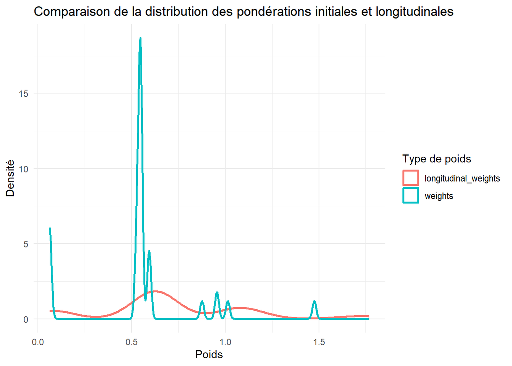

```r
  data_plot_1 <- data_resp_predict_1 %>%
  select(weights, longitudinal_weights) %>%
  pivot_longer(cols = everything(),
               names_to = "type",
               values_to = "weight")

ggplot(data_plot_1, aes(x = weight, color = type)) +
  geom_density(size = 1) +
  labs(
    title = "Comparaison de la distribution des pondérations initiales et longitudinales",
    x = "Poids",
    y = "Densité",
    color = "Type de poids"
  ) +
  theme_minimal()
```

# 6. Calculer l’indicateur d’efficacité de pondération DEFF

Le $\textit{design effect}$ dû aux poids est défini par :
$$DEFF_w = 1 + CV(w)^2$$

où :
$$CV(w) = \frac{sd(w)}{mean(w)}$$

Ainsi :

- si $\text{DEFF} = 1$ : les poids sont tous égaux (situation idéale) ;
- si $\text{DEFF} = 2$ : la variance des poids double la variance des estimations ;
- si $\text{DEFF} > 4$ : les pondérations sont problématiques (souvent dû aux poids extrêmes).

```r
calc_deff <- function(weights) {
  cv <- sd(weights) / mean(weights)
  deff <- 1 + cv^2
  return(deff)
}

deff_initial_0 <- calc_deff(data_resp_predict_0$weights)
print(paste("DEFF initial (baseline):", round(deff_initial_0, 3)))
```

```
[1] "DEFF initial (baseline): 1.273"
```

```r
deff_longitudinal_0 <- calc_deff(data_resp_predict_0$longitudinal_weights)
print(paste("DEFF longitudinal (baseline):", round(deff_longitudinal_0, 3)))
```

```
[1] "DEFF longitudinal (baseline): 1.319"
```

```r
deff_initial_1 <- calc_deff(data_resp_predict_1$weights)
print(paste("DEFF initial (endline):", round(deff_initial_1, 3)))
```

```
[1] "DEFF initial (endline): 1.273"
```

```r
deff_longitudinal_1 <- calc_deff(data_resp_predict_1$longitudinal_weights)
print(paste("DEFF longitudinal (endline):", round(deff_longitudinal_1, 3)))
```

```
[1] "DEFF longitudinal (endline): 1.319"
```